# Machine Learning Project

Joy Payton

August 5, 2016

## The Plan

First, we’ll get our data (both training – what we use to build a model, and testing – what we use to test model effectiveness at prediction). We’ll take a little of our training data to be a validation set, then use the remainder of our training data to construct models. Reserving some validation data will keep us from overfitting to the training data and allows for reduced variability. This is important because of the very tiny size of our testing set. We want to reduce variability even if it means increasing bias a bit, to ameliorate the risk of having a way-off prediction.

Once we’ve got our data squared away, then we’ll do some preliminary modeling on our training data. We’ll try linear modeling, some tree models, random forests, boosting… just getting a rough idea what seems to work. We want to break our training data up into subgroups to do cross-validation (basically, treating various portions of our training data as unknown-outcome test data) as we do this.

Once we think we’ve narrowed things down to a few algorithms that seem to do well, we’ll ensemble or stack them together to get the most accurate prediction we can.

## Getting Set up and Getting our Data

Let’s get some libraries that will come in handy.

```r
library(lattice)
library(ggplot2)
library(caret)
library(e1071)
library(mlbench)
```

And download our data!

```r
training_raw<-read.csv("https://d396qusza40orc.cloudfront.net/predmachlearn/pml-training.csv")
testing<-read.csv("https://d396qusza40orc.cloudfront.net/predmachlearn/pml-testing.csv")
```

We want to take off some of our training data as our validation set, to do a preliminary check on our model error before using our model to predict the testing data and submitting it. We can take a pretty big chunk off, since we have ample data.

```r
set.seed(42)
inTrain<-createDataPartition(y=training_raw$classe, p = 0.60, list=FALSE)
training<-training_raw[inTrain,]
validation<-training_raw[-inTrain,]
```

## Features to use

Given that we already have 160 features, the creation of new ones doesn’t seem very necessary. In fact, we should see if we can remove any that have little information to offer, either because they have close to zero variance from case to case, have lots of missing data, or because they are strongly co-linear with others features.

Let’s first remove any variable that has over 30% NA values across the training cases.

```r
na_count <-sapply(training, function(y) sum(length(which(is.na(y)))))
which(na_count/nrow(training) >= .3)  # show our high NA's
```

```
##            max_roll_belt           max_picth_belt            min_roll_belt
##                       18                       19                       21
##           min_pitch_belt      amplitude_roll_belt     amplitude_pitch_belt
##                       22                       24                       25
##     var_total_accel_belt            avg_roll_belt         stddev_roll_belt
##                       27                       28                       29
##            var_roll_belt           avg_pitch_belt        stddev_pitch_belt
##                       30                       31                       32
##           var_pitch_belt             avg_yaw_belt          stddev_yaw_belt
##                       33                       34                       35
##             var_yaw_belt            var_accel_arm             avg_roll_arm
##                       36                       50                       51
##          stddev_roll_arm             var_roll_arm            avg_pitch_arm
##                       52                       53                       54
##         stddev_pitch_arm            var_pitch_arm              avg_yaw_arm
##                       55                       56                       57
##           stddev_yaw_arm              var_yaw_arm             max_roll_arm
##                       58                       59                       75
##            max_picth_arm              max_yaw_arm             min_roll_arm
##                       76                       77                       78
##            min_pitch_arm              min_yaw_arm       amplitude_roll_arm
##                       79                       80                       81
##      amplitude_pitch_arm        amplitude_yaw_arm        max_roll_dumbbell
##                       82                       83                       93
##       max_picth_dumbbell        min_roll_dumbbell       min_pitch_dumbbell
##                       94                       96                       97
##  amplitude_roll_dumbbell amplitude_pitch_dumbbell       var_accel_dumbbell
##                       99                      100                      103
##        avg_roll_dumbbell     stddev_roll_dumbbell        var_roll_dumbbell
##                      104                      105                      106
##       avg_pitch_dumbbell    stddev_pitch_dumbbell       var_pitch_dumbbell
##                      107                      108                      109
##         avg_yaw_dumbbell      stddev_yaw_dumbbell         var_yaw_dumbbell
##                      110                      111                      112
##         max_roll_forearm        max_picth_forearm         min_roll_forearm
##                      131                      132                      134
##        min_pitch_forearm   amplitude_roll_forearm  amplitude_pitch_forearm
##                      135                      137                      138
##        var_accel_forearm         avg_roll_forearm      stddev_roll_forearm
##                      141                      142                      143
##         var_roll_forearm        avg_pitch_forearm     stddev_pitch_forearm
##                      144                      145                      146
##        var_pitch_forearm          avg_yaw_forearm       stddev_yaw_forearm
##                      147                      148                      149
##          var_yaw_forearm
##                      150
```

```r
training<-training[,-which(na_count/nrow(training) >= .3)]
# To keep things looking the same, do the same cleanup on validation and testing.
validation<-validation[,-which(na_count/nrow(training) >= .3)]
testing<-testing[,-which(na_count/nrow(training) >= .3)]
```

We should also remove the username and row number because we want this model to be applicable not just to our current user set, but to anyone who uses the equipment.

```r
training<-training[,-c(1,2)]
validation<-validation[,-c(1,2)]
testing<-testing[,-c(1,2)]
```

Let’s remove near zero variation features (as found in training) from all three of our datasets.

```r
nsv<-nearZeroVar(training)
training<-training[,-nsv]
validation<-validation[,-nsv]
testing<-testing[,-nsv]
```

This removal of variables gets us down to 57 variables, which seems much more doable as far as processor load!

Still, let’s take a look at correlation to see how highly correlated things seem to be:

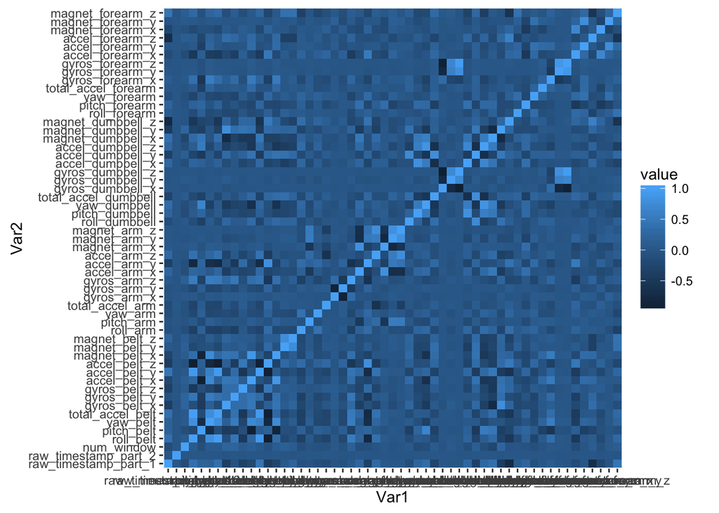

```r
library(ggplot2)
library(reshape2)
corr<-cor(training[which(sapply(training,is.numeric))])
qplot(x=Var1, y=Var2, data=melt(corr), fill=value, geom="tile")
```

There are some bright and dark spots with high correlation, which may point us in the direction of reducing by selection. I’m going to take a blunt force approach and remove one of each pair of features that has strong correlation (absolute value greater than or equal to 0.75).

```r
corr[upper.tri(corr)]<-0  # this way I only pick one of the mirror-imaged highly correlated pair
diag(corr)<-0 # and I don't remove the highly-correlated-with-itself group
training<-training[,!apply(corr,2, function(x) any(abs(x)>=0.75))]
validation<-validation[,!apply(corr,2, function(x) any(abs(x)>=0.75))]
testing<-testing[,!apply(corr,2, function(x) any(abs(x)>=0.75))]
```

That gets us down to 33 variables, which is far more doable than the 160 we started with!

We may have to pare down further by means of PCA, regularized regression, or random forest pruning. For now, we’ll start with all of them and see what that gets us.

At this point, I first attempted to go ahead with LDA classification, only to discover I had a *perfect* predictor! That made me suspicious that I was missing something very obvious, which indeed I was.

When I looked anew at the original data, saw a pattern:

```r
head(table(training_raw$num_window,training_raw$classe))
```

```
##
##      A  B  C  D  E
##   1  0  0  0  0 20
##   2  0  0  0  0 21
##   3  0  0  0  0  3
##   4  0  0  0  0 28
##   5  0  0  0  0 21
##   6  0  0  0  0 21
```

```r
tail(table(training_raw$num_window,training_raw$classe))
```

```
##
##        A  B  C  D  E
##   859  0 27  0  0  0
##   860  0 26  0  0  0
##   861  0 25  0  0  0
##   862 31  0  0  0  0
##   863  0  0  0  0 12
##   864  0  0  0  0 14
```

```r
head(table(training_raw$cvtd_timestamp, training_raw$classe))
```

```
##
##                      A   B   C   D   E
##   02/12/2011 13:32 177   0   0   0   0
##   02/12/2011 13:33 988 333   0   0   0
##   02/12/2011 13:34   0 443 750 182   0
##   02/12/2011 13:35   0   0   0 333 686
##   02/12/2011 14:56 235   0   0   0   0
##   02/12/2011 14:57 664 716   0   0   0
```

```r
tail(table(training_raw$cvtd_timestamp, training_raw$classe))
```

```
##
##                      A   B   C   D   E
##   28/11/2011 14:13 833   0   0   0   0
##   28/11/2011 14:14  32 592 489 385   0
##   28/11/2011 14:15   0   0   0 197 542
##   30/11/2011 17:10 869   0   0   0   0
##   30/11/2011 17:11 308 489 643   0   0
##   30/11/2011 17:12   0   0   9 522 562
```

The “window” is a time-series window, closely related to the timestamp, and each window contains the multiple datapoints that, together, represent a cohesive weight-lifting move. Rookie mistake! It’s easy to perfectly predict if you know the right matchup between time of day or window ID and the activity being done. My model wasn’t really predicting anything interesting. I’ll remove the two remaining time-related values (two were already removed) to see if I can still get good results out of my model.

```r
training<-training[,-c(1,2)]
validation<-validation[,-c(1,2)]
testing<-testing[,-c(1,2)]
```

### Linear Discriminant Analysis

We’ll set the training control for all of our modeling attempts, and use it for our LDA model attempt.

```r
tctrl=trainControl(method="cv", number = 10)

set.seed(42)
lda_model<-train(classe ~ ., data=training, method="lda", trControl=tctrl)
confusionMatrix(training$classe, predict(lda_model,training))
```

```
## Confusion Matrix and Statistics
##
##           Reference
## Prediction    A    B    C    D    E
##          A 2281  249  438  338   42
##          B  494 1138  301  186  160
##          C  335  184 1243  244   48
##          D   94  245  277 1131  183
##          E  111  375  258  367 1054
##
## Overall Statistics
##
##                Accuracy : 0.5814
##                  95% CI : (0.5725, 0.5904)
##     No Information Rate : 0.2815
##     P-Value [Acc > NIR] : < 2.2e-16
##
##                   Kappa : 0.4715
##  Mcnemar's Test P-Value : < 2.2e-16
##
## Statistics by Class:
##
##                      Class: A Class: B Class: C Class: D Class: E
## Sensitivity            0.6881  0.51940   0.4938  0.49912   0.7088
## Specificity            0.8739  0.88096   0.9124  0.91598   0.8920
## Pos Pred Value         0.6813  0.49934   0.6052  0.58601   0.4868
## Neg Pred Value         0.8773  0.88912   0.8690  0.88472   0.9549
## Prevalence             0.2815  0.18606   0.2137  0.19243   0.1263
## Detection Rate         0.1937  0.09664   0.1056  0.09604   0.0895
## Detection Prevalence   0.2843  0.19353   0.1744  0.16389   0.1838
## Balanced Accuracy      0.7810  0.70018   0.7031  0.70755   0.8004
```

58% Accuracy. Let’s see how it performs on the validation set!

```r
confusionMatrix(validation$classe, predict(lda_model, validation))
```

```
## Confusion Matrix and Statistics
##
##           Reference
## Prediction    A    B    C    D    E
##          A 1500  144  314  247   27
##          B  331  747  210  126  104
##          C  190  107  872  169   30
##          D   75  129  218  742  122
##          E   92  269  154  269  658
##
## Overall Statistics
##
##                Accuracy : 0.576
##                  95% CI : (0.5649, 0.5869)
##     No Information Rate : 0.2789
##     P-Value [Acc > NIR] : < 2.2e-16
##
##                   Kappa : 0.4649
##  Mcnemar's Test P-Value : < 2.2e-16
##
## Statistics by Class:
##
##                      Class: A Class: B Class: C Class: D Class: E
## Sensitivity            0.6856  0.53510   0.4932  0.47778  0.69926
## Specificity            0.8706  0.88047   0.9184  0.91355  0.88646
## Pos Pred Value         0.6720  0.49209   0.6374  0.57698  0.45631
## Neg Pred Value         0.8774  0.89744   0.8617  0.87637  0.95581
## Prevalence             0.2789  0.17793   0.2253  0.19794  0.11993
## Detection Rate         0.1912  0.09521   0.1111  0.09457  0.08386
## Detection Prevalence   0.2845  0.19347   0.1744  0.16391  0.18379
## Balanced Accuracy      0.7781  0.70778   0.7058  0.69567  0.79286
```

Close to 58% accuracy here as well! At least we don’t seem to be overfitting too much, but we could improve that accuracy a fair bit, I believe.

### Random Forest

```r
set.seed(42)
rf_model<-train(classe ~ ., data=training, method="rf", trControl=tctrl)
confusionMatrix(training$classe, predict(rf_model,training))
```

```
## Confusion Matrix and Statistics
##
##           Reference
## Prediction    A    B    C    D    E
##          A 3348    0    0    0    0
##          B    0 2279    0    0    0
##          C    0    0 2054    0    0
##          D    0    0    0 1930    0
##          E    0    0    0    0 2165
##
## Overall Statistics
##
##                Accuracy : 1
##                  95% CI : (0.9997, 1)
##     No Information Rate : 0.2843
##     P-Value [Acc > NIR] : < 2.2e-16
##
##                   Kappa : 1
##  Mcnemar's Test P-Value : NA
##
## Statistics by Class:
##
##                      Class: A Class: B Class: C Class: D Class: E
## Sensitivity            1.0000   1.0000   1.0000   1.0000   1.0000
## Specificity            1.0000   1.0000   1.0000   1.0000   1.0000
## Pos Pred Value         1.0000   1.0000   1.0000   1.0000   1.0000
## Neg Pred Value         1.0000   1.0000   1.0000   1.0000   1.0000
## Prevalence             0.2843   0.1935   0.1744   0.1639   0.1838
## Detection Rate         0.2843   0.1935   0.1744   0.1639   0.1838
## Detection Prevalence   0.2843   0.1935   0.1744   0.1639   0.1838
## Balanced Accuracy      1.0000   1.0000   1.0000   1.0000   1.0000
```

Wow, that took *forever*, but does seem to have perfect accuracy… could it be? Let’s apply the model to the validation dataset to see how it holds up.

```r
confusionMatrix(validation$classe, predict(rf_model,validation))
```

```
## Confusion Matrix and Statistics
##
##           Reference
## Prediction    A    B    C    D    E
##          A 2229    2    0    1    0
##          B   15 1500    3    0    0
##          C    0   15 1352    1    0
##          D    0    0   39 1246    1
##          E    0    6    0   10 1426
##
## Overall Statistics
##
##                Accuracy : 0.9881
##                  95% CI : (0.9855, 0.9904)
##     No Information Rate : 0.286
##     P-Value [Acc > NIR] : < 2.2e-16
##
##                   Kappa : 0.985
##  Mcnemar's Test P-Value : NA
##
## Statistics by Class:
##
##                      Class: A Class: B Class: C Class: D Class: E
## Sensitivity            0.9933   0.9849   0.9699   0.9905   0.9993
## Specificity            0.9995   0.9972   0.9975   0.9939   0.9975
## Pos Pred Value         0.9987   0.9881   0.9883   0.9689   0.9889
## Neg Pred Value         0.9973   0.9964   0.9935   0.9982   0.9998
## Prevalence             0.2860   0.1941   0.1777   0.1603   0.1819
## Detection Rate         0.2841   0.1912   0.1723   0.1588   0.1817
## Detection Prevalence   0.2845   0.1935   0.1744   0.1639   0.1838
## Balanced Accuracy      0.9964   0.9910   0.9837   0.9922   0.9984
```

Not perfect, but not too shabby at almost 99% accuracy!

### Stochastic Gradient Boosting

Let’s try boosting. I’ll hide the results so we don’t get a huge output.

```r
set.seed(42)
boost_model<-train(classe ~ ., data=training, method="gbm", trControl=tctrl)
```

What kind of accuracy do we see in training and validation?

```r
confusionMatrix(training$classe, predict(boost_model,training))
```

```
## Confusion Matrix and Statistics
##
##           Reference
## Prediction    A    B    C    D    E
##          A 3281   38   15    9    5
##          B  131 2029   99    7   13
##          C   11   88 1920   31    4
##          D    5   20  113 1774   18
##          E    5   36   52   51 2021
##
## Overall Statistics
##
##                Accuracy : 0.9362
##                  95% CI : (0.9317, 0.9406)
##     No Information Rate : 0.2915
##     P-Value [Acc > NIR] : < 2.2e-16
##
##                   Kappa : 0.9193
##  Mcnemar's Test P-Value : < 2.2e-16
##
## Statistics by Class:
##
##                      Class: A Class: B Class: C Class: D Class: E
## Sensitivity            0.9557   0.9177   0.8731   0.9476   0.9806
## Specificity            0.9920   0.9739   0.9860   0.9842   0.9852
## Pos Pred Value         0.9800   0.8903   0.9348   0.9192   0.9335
## Neg Pred Value         0.9820   0.9808   0.9713   0.9900   0.9958
## Prevalence             0.2915   0.1878   0.1867   0.1590   0.1750
## Detection Rate         0.2786   0.1723   0.1630   0.1506   0.1716
## Detection Prevalence   0.2843   0.1935   0.1744   0.1639   0.1838
## Balanced Accuracy      0.9738   0.9458   0.9296   0.9659   0.9829
```

```r
confusionMatrix(validation$classe, predict(boost_model,validation))
```

```
## Confusion Matrix and Statistics
##
##           Reference
## Prediction    A    B    C    D    E
##          A 2164   29   17   17    5
##          B   89 1302   97   17   13
##          C    6   67 1273   18    4
##          D    5   24   88 1154   15
##          E    6   54   45   49 1288
##
## Overall Statistics
##
##                Accuracy : 0.9152
##                  95% CI : (0.9089, 0.9213)
##     No Information Rate : 0.2893
##     P-Value [Acc > NIR] : < 2.2e-16
##
##                   Kappa : 0.8927
##  Mcnemar's Test P-Value : < 2.2e-16
##
## Statistics by Class:
##
##                      Class: A Class: B Class: C Class: D Class: E
## Sensitivity            0.9533   0.8821   0.8375   0.9195   0.9721
## Specificity            0.9878   0.9661   0.9850   0.9800   0.9764
## Pos Pred Value         0.9695   0.8577   0.9306   0.8974   0.8932
## Neg Pred Value         0.9811   0.9725   0.9619   0.9846   0.9942
## Prevalence             0.2893   0.1881   0.1937   0.1600   0.1689
## Detection Rate         0.2758   0.1659   0.1622   0.1471   0.1642
## Detection Prevalence   0.2845   0.1935   0.1744   0.1639   0.1838
## Balanced Accuracy      0.9706   0.9241   0.9112   0.9497   0.9742
```

Boosting does well, too, at 94% accuracy on the training data set and 92% accuracy on the validation set.

And for fun, let’s do one more, Naive Bayes!

### Naive Bayes

```r
set.seed(42)
naiveb_model<-train(classe ~ ., data=training, method="nb", trControl=tctrl)
confusionMatrix(training$classe, predict(naiveb_model,training))
```

```
## Confusion Matrix and Statistics
##
##           Reference
## Prediction    A    B    C    D    E
##          A 3085   42   44  135   42
##          B  588 1396  156   95   44
##          C  571  138 1272   62   11
##          D  454    6  129 1238  103
##          E  203  241  104  112 1505
##
## Overall Statistics
##
##                Accuracy : 0.7215
##                  95% CI : (0.7133, 0.7296)
##     No Information Rate : 0.4162
##     P-Value [Acc > NIR] : < 2.2e-16
##
##                   Kappa : 0.6415
##  Mcnemar's Test P-Value : < 2.2e-16
##
## Statistics by Class:
##
##                      Class: A Class: B Class: C Class: D Class: E
## Sensitivity            0.6295   0.7658   0.7460   0.7540   0.8827
## Specificity            0.9617   0.9113   0.9224   0.9317   0.9345
## Pos Pred Value         0.9214   0.6125   0.6193   0.6415   0.6952
## Neg Pred Value         0.7845   0.9550   0.9555   0.9590   0.9792
## Prevalence             0.4162   0.1548   0.1448   0.1394   0.1448
## Detection Rate         0.2620   0.1185   0.1080   0.1051   0.1278
## Detection Prevalence   0.2843   0.1935   0.1744   0.1639   0.1838
## Balanced Accuracy      0.7956   0.8385   0.8342   0.8428   0.9086
```

```r
confusionMatrix(validation$classe, predict(naiveb_model,validation))
```

```
## Confusion Matrix and Statistics
##
##           Reference
## Prediction    A    B    C    D    E
##          A 2029   22   36  113   32
##          B  368  918  111   84   37
##          C  382   89  839   47   11
##          D  314    0   95  800   77
##          E  138  169   67   83  985
##
## Overall Statistics
##
##                Accuracy : 0.71
##                  95% CI : (0.6999, 0.7201)
##     No Information Rate : 0.4118
##     P-Value [Acc > NIR] : < 2.2e-16
##
##                   Kappa : 0.6271
##  Mcnemar's Test P-Value : < 2.2e-16
##
## Statistics by Class:
##
##                      Class: A Class: B Class: C Class: D Class: E
## Sensitivity            0.6280   0.7663   0.7308   0.7098   0.8625
## Specificity            0.9560   0.9097   0.9210   0.9277   0.9318
## Pos Pred Value         0.9091   0.6047   0.6133   0.6221   0.6831
## Neg Pred Value         0.7859   0.9558   0.9523   0.9502   0.9755
## Prevalence             0.4118   0.1527   0.1463   0.1436   0.1456
## Detection Rate         0.2586   0.1170   0.1069   0.1020   0.1255
## Detection Prevalence   0.2845   0.1935   0.1744   0.1639   0.1838
## Balanced Accuracy      0.7920   0.8380   0.8259   0.8188   0.8972
```

Not great – 72% accuracy on the training set, and 71% accuracy on the validation set.

At this point, we have two terrific models that are >90% accurate in both the training and validation set. The Random Forest model is good enough to go by itself, I think, but let’s see if there are any cases where Random Forest missed it but Stochastic Boosting got it right. That will help me decide if I want to use these two models together somehow. I’ll look in validation, since the Random Forest got 100% in training!

```r
predictions<-data.frame(cbind(predict(rf_model,validation), predict(boost_model,validation), validation$classe))
names(predictions)<-c("rf","boost","actual")
predictions$rf<-as.factor(predictions$rf)
predictions$boost<-as.factor(predictions$boost)
predictions$actual<-as.factor(predictions$actual)
table(predictions$rf!=predictions$actual & predictions$boost == predictions$actual)
```

```
##
## FALSE  TRUE
##  7822    24
```

Well, RF only misses 24 that Boost gets. But the converse, where RF is right and Boost is not, is larger:

```r
table(predictions$rf==predictions$actual & predictions$boost != predictions$actual)
```

```
##
## FALSE  TRUE
##  7250   596
```

There doesn’t seem much to gain from ensembling, when Random Forest does so well. Because the percentage accuracy is almost the same between training and validation, I don’t think I have an overfitting problem, and I anticipate the test accuracy to be over 90%.

I’ll go ahead and predict now.

```r
predict(rf_model,testing)
```

```
##  [1] B A B A A E D B A A B C B A E E A B B B
## Levels: A B C D E
```

After submitting to the portal, I have an actual rate of 100%! Yay!